# MATH 106 - Applied Linear Statistical Models

mbanuelos22@csufresno.edu

## Goals for Today

- Quiz 2 Solutions
- Introduction to Multiple Linear Regression
- Added-Variable Plots

## Ch. 3 Adding a Regressor

We start with a response \(Y\) and the simple linear regression mean function

\[ \text{E}(Y | X_1 = x_1 )= \beta_0 + \beta_1 x_1\ \]

Now suppose we have a second variable \(X_2\). Then the mean function becomes

\[ \text{E}(Y | X_1 = x_1 , X_2 = x_2)= \beta_0 + \beta_1 x_1 + \beta_2 x_2 \]

**Goal:** Adding \(X_2\) attempts to explain the part of \(Y\) not explained by \(X_1\).

## Multiple Linear Regression

The general multiple linear regression model with response \(Y\) and regressors \(X_1, X_2, \ldots X_p\) takes the form

\[ \text{E}( Y | X ) = \beta_0 + \beta_1 X_1 + \ldots + \beta_p X_p \]

When we condition on \(X\), we will collect \(x_1, x_2, \ldots x_p\) into \({\bf x}\) (the predictors) and have

\[ \text{E}(Y | X = {\bf x}) = \beta_0 + \beta_1 x_1 + \ldots + \beta_p x_p \]

## United Nations Data

You may have previously predicted life expectancy with `log(ppgdp)`, but what about if you add `fertility`?

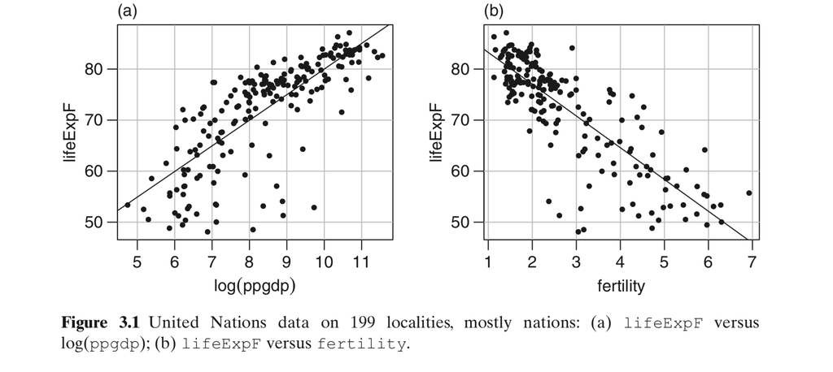

## United Nations Data

**Note:=** a) \(R^2 = 0.60\), b) \(R^2 = 0.64\)

**Q:** Why don’t both explain 124% of the variance?

**Correlation!**

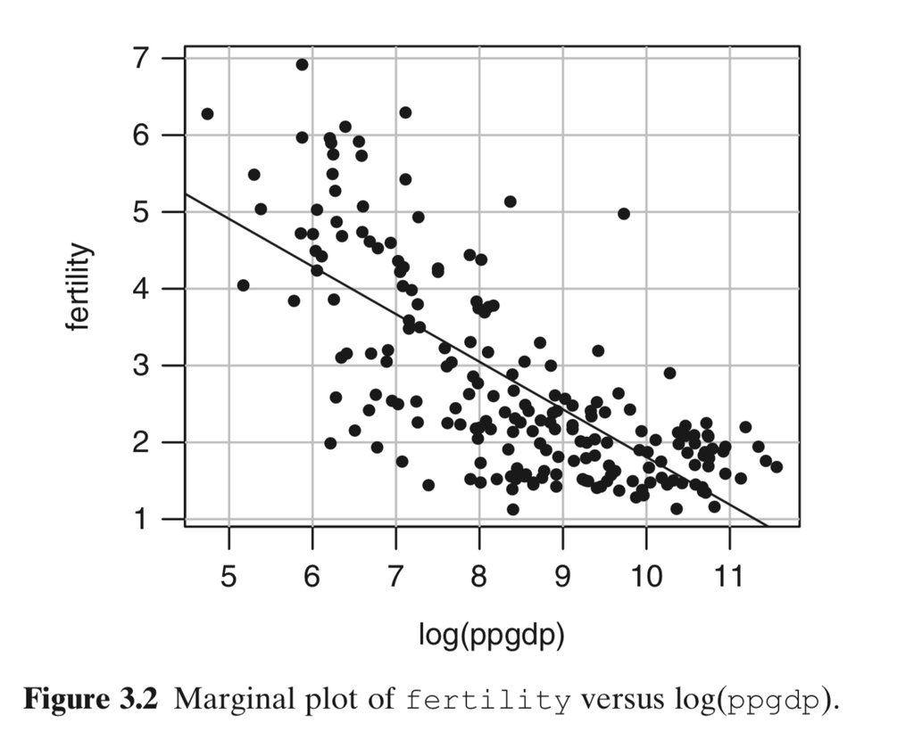

## Predictors vs Regressors

- The Intercept
- Predictors
- Polynomials
- Interaction terms
- Dummy variables and factors
- Regression splines
- Principal components

## Multiple Linear Regression

The multiple linear regression model with response \(Y\) and regressors \(X_1, X_2\) takes the form

\[ \text{E}( Y | X ) = \beta_0 + \beta_1 X_1 + \beta_2 X_2 \]

## 3.1.2 Added-Variable Plots

To get the effect of adding \(X_2\) to the model that already includes \(X_1\), we need to examine the part of \(Y\) not explained by \(X_1\) **and** the part of \(X_2\) not explained by \(X_1\). We will do the following:

1. Compute the regression of response \(Y\) on \(X_1\). Keep the residuals from this regression. This is the part of \(Y\) **not explained by** \(X_1\).
2. Compute the regression of response \(X_2\) on \(X_1\). Keep the residuals. This is the part of \(X_2\) **not explained by** \(X_1\).
3. The **added-variable plot** is the unexplained part of the response from (1) on unexplained part of (2).

## \(F\) - Statistic

We define the \(F\) statistic as

\[ F = \frac{ \text{explained variance} }{\text{ unexplained variance}}, \]

and is a ratio of two \(\chi^2\) random variables.

**Q:** How many parameters does the \(F\)-statistic have?